# Estimación del número de pasajeros de aerolíneas internacionales

DataScienceLab

20 de marzo de 2021

# 1 Carga de paquetes

```r
for (package in c("tidyverse","fpp3", "GGally", "normtest")) {
    if (!require(package, character.only=T, quietly=T)) {
        install.packages(package)
        library(package, character.only=T)
    }
}
```

# 2 Funciones auxiliares

```r
# Contraste para los coeficientes
my_t_test <- function (object, ...)
{
  par <- rbind(t_stat=tidy(object)$statistic, p_value=tidy(object)$p.value)
  colnames(par) <- tidy(object)$term
  if (NCOL(par) > 0) {
    cat("\nt-test:\n")
    coef <- round(par, digits = 4)
    print.default(coef, print.gap = 2)
  }
}

# Gráfico de correlogramas de residuos
my_tsresiduals <- function (data, ...) {
  if (!fabletools::is_mable(data)) {
    abort("gg_tsresiduals() must be used with a mable containing only one model.")
  }
  data <- stats::residuals(data)
  if (n_keys(data) > 1) {
    abort("gg_tsresiduals() must be used with a mable containing only one model.")
  }
  gg_tsdisplay(data, !!sym(".resid"), plot_type = "partial",
    ...)
}

# Validación cruzada anidada

nested_cv <- function(df, h, last_train, string_formula){

  nested_errors <- vector()

for (i in seq(last_train, last(df$date), h)){
  train <- df %>% filter(date<=i)
  test <- df %>% filter(date>i)

fitted_model <- train %>%
  model(arima = ARIMA(as.formula(string_formula)))

h_forecast = min(dim(test)[1], h)

fc <- fitted_model %>%
  forecast(h=h_forecast)

test_err <- fc %>%
  accuracy(test) %>%
  select(MAPE)
nested_errors <- c(nested_errors, test_err$MAPE)
NewList <- list("errors"=nested_errors, "mean"=mean(nested_errors))
}
return(NewList)}

# Test de autocorrelacines de los residuos
autocorrelation_test_plot <- function(aug, dof = 4, m = 7,  h = 5, alpha = 0.05){
vec <- c()
num_lags = seq(1, h*m)

for (i in num_lags){
 vec <- c(vec,aug %>% features(.resid, ljung_box, lag=i, dof=dof) %>% .$lb_pvalue)
}

autocorr_pvalues_resid <- tibble(
  lag = num_lags,
  p_value = vec,
  incorelated = p_value >= alpha
)

plot <- autocorr_pvalues_resid %>%
  drop_na() %>%
   ggplot(aes(lag, p_value, color = incorelated)) +
  geom_point() +
  geom_hline(aes(yintercept = alpha), linetype="dashed", color = "indianred2")


newList <- list("values" = autocorr_pvalues_resid, "plot" = plot)
return(newList)
}

# Autocorrelaciones de los residuos opción 2

resid_corr <- function(modelo, dof_modelo, estacionalidad, show_pvals = TRUE){
  pvals <- c()
  for (lag_i in seq(1, 2*estacionalidad)) {
    pormateau_i <- modelo %>% features(.resid, ljung_box, lag = lag_i, dof = dof_modelo)
    pvals <- c(pvals, pormateau_i$lb_pvalue)

  }
  if (show_pvals) {
    plot(pvals)
     abline(0.05, 0)
  }

  return(pvals)
}
```

# 3 División train y test

Antes de empezar a hacer el estudio hay que distinguir la parte de los datos que se utilizará para construir la fórmula (para modelizar) de aquella que se utilizará para validar los resultados y cuyos datos, no deben ser utilizados.

Convertimos la serie en un objeto **tsibble**, para trabajar de manera cómoda. Analizamos visualmente la serie y las marcas de tiempo para saber cómo dividir los datos.

```r
air = as_tsibble(AirPassengers, index = date)
air$index
```

```
## <yearmonth[144]>
##   [1] "1949 ene" "1949 feb" "1949 mar" "1949 abr" "1949 may" "1949 jun"
##   [7] "1949 jul" "1949 ago" "1949 sep" "1949 oct" "1949 nov" "1949 dic"
##  [13] "1950 ene" "1950 feb" "1950 mar" "1950 abr" "1950 may" "1950 jun"
##  [19] "1950 jul" "1950 ago" "1950 sep" "1950 oct" "1950 nov" "1950 dic"
##  [25] "1951 ene" "1951 feb" "1951 mar" "1951 abr" "1951 may" "1951 jun"
##  [31] "1951 jul" "1951 ago" "1951 sep" "1951 oct" "1951 nov" "1951 dic"
##  [37] "1952 ene" "1952 feb" "1952 mar" "1952 abr" "1952 may" "1952 jun"
##  [43] "1952 jul" "1952 ago" "1952 sep" "1952 oct" "1952 nov" "1952 dic"
##  [49] "1953 ene" "1953 feb" "1953 mar" "1953 abr" "1953 may" "1953 jun"
##  [55] "1953 jul" "1953 ago" "1953 sep" "1953 oct" "1953 nov" "1953 dic"
##  [61] "1954 ene" "1954 feb" "1954 mar" "1954 abr" "1954 may" "1954 jun"
##  [67] "1954 jul" "1954 ago" "1954 sep" "1954 oct" "1954 nov" "1954 dic"
##  [73] "1955 ene" "1955 feb" "1955 mar" "1955 abr" "1955 may" "1955 jun"
##  [79] "1955 jul" "1955 ago" "1955 sep" "1955 oct" "1955 nov" "1955 dic"
##  [85] "1956 ene" "1956 feb" "1956 mar" "1956 abr" "1956 may" "1956 jun"
##  [91] "1956 jul" "1956 ago" "1956 sep" "1956 oct" "1956 nov" "1956 dic"
##  [97] "1957 ene" "1957 feb" "1957 mar" "1957 abr" "1957 may" "1957 jun"
## [103] "1957 jul" "1957 ago" "1957 sep" "1957 oct" "1957 nov" "1957 dic"
## [109] "1958 ene" "1958 feb" "1958 mar" "1958 abr" "1958 may" "1958 jun"
## [115] "1958 jul" "1958 ago" "1958 sep" "1958 oct" "1958 nov" "1958 dic"
## [121] "1959 ene" "1959 feb" "1959 mar" "1959 abr" "1959 may" "1959 jun"
## [127] "1959 jul" "1959 ago" "1959 sep" "1959 oct" "1959 nov" "1959 dic"
## [133] "1960 ene" "1960 feb" "1960 mar" "1960 abr" "1960 may" "1960 jun"
## [139] "1960 jul" "1960 ago" "1960 sep" "1960 oct" "1960 nov" "1960 dic"
```

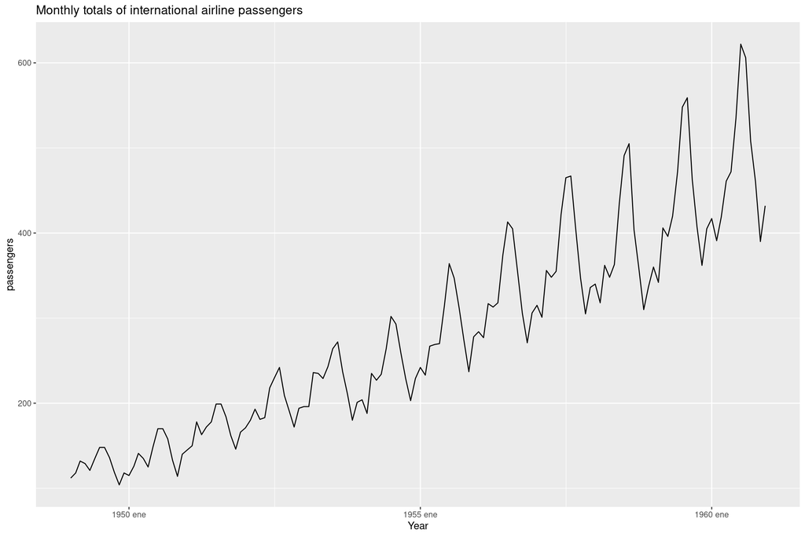

```r
air %>%
  autoplot(value) +
    labs(title = "Monthly totals of international airline passengers") +
    xlab("Year") + ylab("passengers")
```

Dado que tenemos datos mensuales y parece existir a simple vista un patrón estacional anual, reservamos el último años para test y el resto para train.

```r
air_train <- air %>% filter_index(. ~ "1959-12")
air_test <- air %>% filter_index("1960-01" ~ .)
```

# 4 Fase de identificación

Se comienza la fase de identificación donde se deciden las transformaciones a realizar y el propio ajuste de la serie. Aunque veremos que cuando se realiza la selección de los parámetros del modelo ARIMA, la iteración con la estimación y el contraste son constantes hasta converger a un modelo válido.

## 4.1 Estacionariedad

Antes de analizar la serie mediante test estadísticos, analicemos gráficamente más en detalle, para confirmar la estacionalidad detectada.

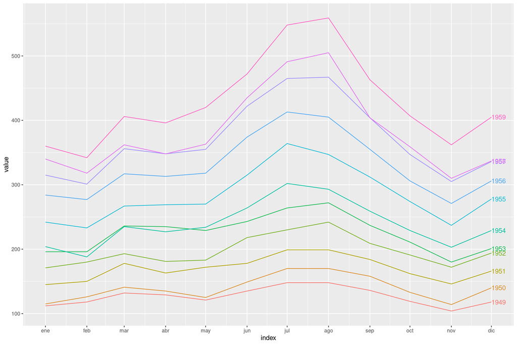

```r
air_train %>%
gg_season(value, labels = "right")
```

Parece claro mediante este gráfico que hay una componente estacional anual, dado que la forma de las series anuales son iguales. Además, se observa que el valor aumenta cada año por lo que parece que tampoco es estable en media.

Dadas las características de la serie, también podemos calcular la descomposición SEATS para corroborar que existe tendencia y estacionalidad.

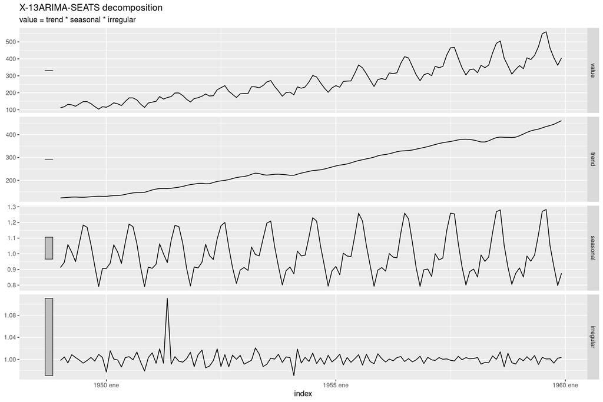

```r
air_train %>%
   model(seats = feasts:::SEATS(value)) %>%
  components() %>%
  autoplot()
```

### Estacionariedad en varianza

Analicemos qué transformación Box-Cox puede aplicarse para estabilizar la varianza.

```r
lambda <- air_train %>%
features(value, features = guerrero) %>% pull(lambda_guerrero)
lambda
```

```
## [1] -0.3055775
```

Dado que es un valor muy próximo a 0, realizaremos un logaritmo a la serie.

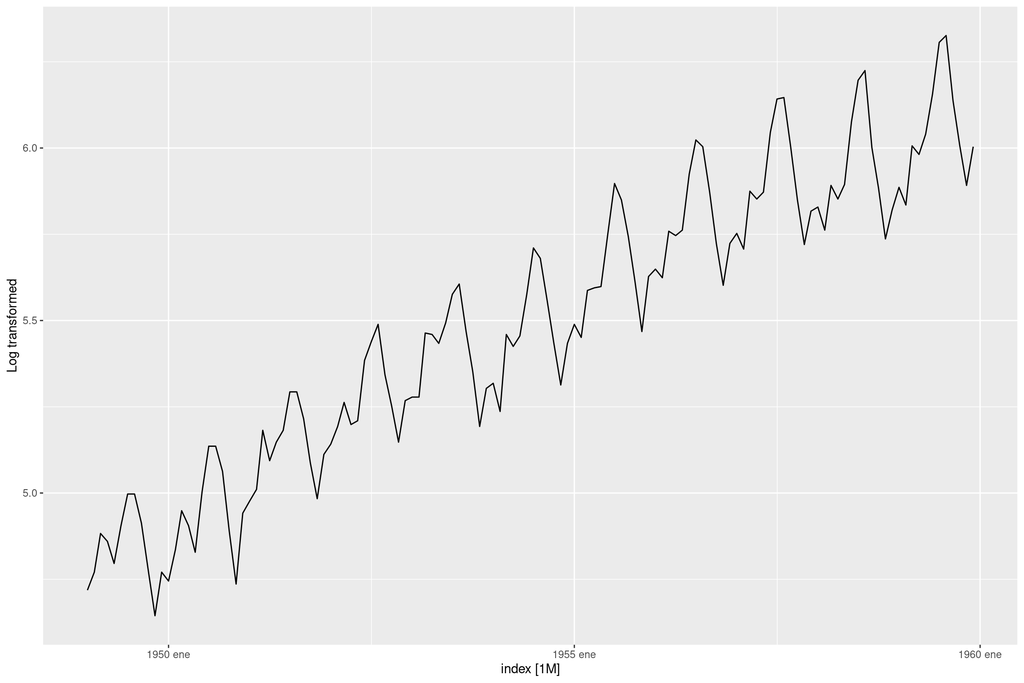

```r
air_train %>% autoplot(log(value)) +
labs(y = "Log transformed")
```

### Estacionariedad en media

Es evidente que se necesita realizar al menos una diferencia para estabilizar la media. Esto se puede comprobar mediante una prueba de raices unitarias.

```r
air_train %>%
  features(log(value), unitroot_kpss)
```

| kpss_stat | kpss_pvalue |
| --- | --- |
| 2.595142 | 0.01 |

El p-valor es menor que 0.05, lo que indica que la hipótesis nula es rechazada. Es decir, los datos no son estacionarios. Se confirma formalmente que los datos no son estacionarios.

```r
air_train %>%
  features(difference(log(value), 1), unitroot_kpss)
```

| kpss_stat | kpss_pvalue |
| --- | --- |
| 0.02635058 | 0.1 |

La serie ya pasa el test, por tanto se puede concluir que hay que realizar una diferencia regular.

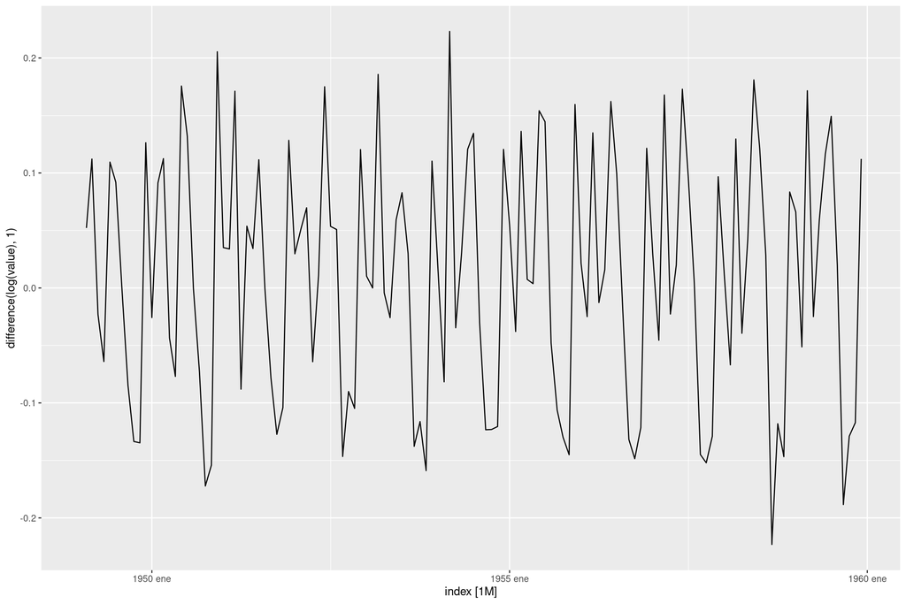

```r
air_train %>% autoplot(difference(log(value), 1))
```

Debido a la estacionalidad de los datos, quizá deba realizarse una diferencia estacional. Para evaluarlo podemos recurrir a la función **unitroot_nsdiffs()**, esta evalúa el estadístico fuerza estacional $F_S$ y sugiere una diferencia estacional si esta es mayor que 0.64.

```r
air_train %>%
  mutate(log_turnover = difference(log(value),1)) %>%
  features(log_turnover, unitroot_nsdiffs)
```

| nsdiffs |
| --- |
| 1 |

Efectivamente, el método sugiere una diferencia estacional como habíamos sospechado.

## 4.2 Determinación del modelo

En los pasos previos hemos detectado la necesidad de realizar una transformación logaritmo, una diferencia regular y otra estacional. Por tanto, comenzaremos con el ajuste de un modelo SARIMA (0,1,0)x(0,1,0)$_{12}$, sobre el logaritmo de la serie.

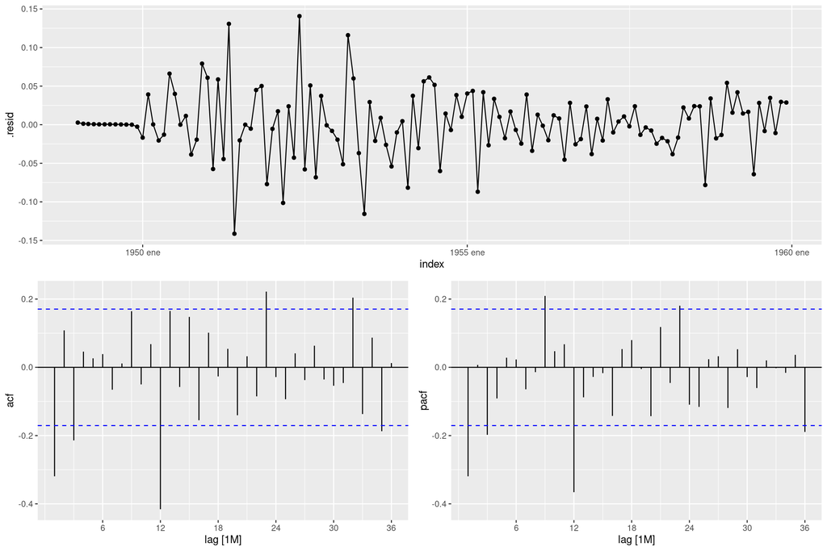

```r
fit <- air_train %>%
  model(arima = ARIMA(log(value) ~ pdq(0,1,0) + PDQ(0,1,0)))
fit %>% my_tsresiduals(lag_max =36)
```

En ambos gráficos de autocorrelaciones se aprecia que el primer pico sobresale de las bandas en ambos casos y el que más sobresale es el 12. Además, se observan decrecimientos estacionales en el PACF, por lo que se puede intuir una AR($\inf$) que sugiere ajustar un MA finito estacional.

# 5 Fase de estimación y contraste

Comencemos ajustando la parte regular mediante un SARIMA (0,1,1)x(0,1,0)$_{12}$

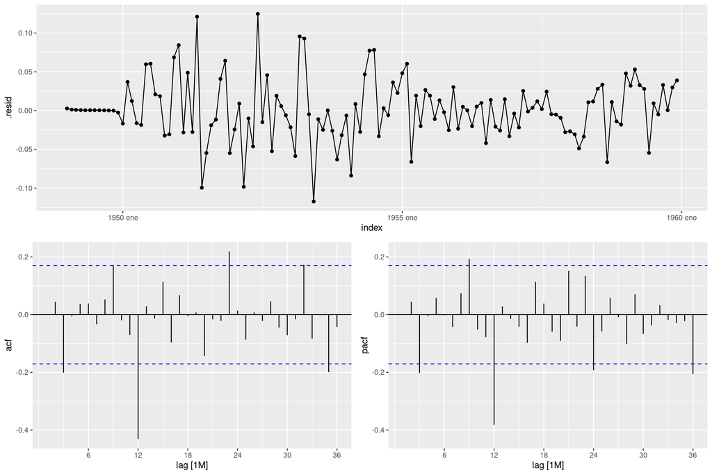

```r
fit2 <- air_train %>%
  model(arima = ARIMA(log(value) ~ pdq(0,1,1) + PDQ(0,1,0)))
fit2 %>% my_tsresiduals(lag_max =36)
```

Muchos de los picos quedan dentro de las bandas, pero parece que va a ser necesario un ajuste de la parte estacional como observamos en la fase previa.

Comprobemos ahora la calidad estadística de este modelo.

```r
report(fit2)
```

```
## Series: value
## Model: ARIMA(0,1,1)(0,1,0)[12]
## Transformation: log(value)
##
## Coefficients:
##           ma1
##       -0.3452
## s.e.   0.0938
##
## sigma^2 estimated as 0.001824:  log likelihood=206.93
## AIC=-409.85   AICc=-409.75   BIC=-404.3
```

```r
my_t_test(fit2)
```

```
##
## t-test:
##              ma1
## t_stat   -3.6816
## p_value   0.0003
```

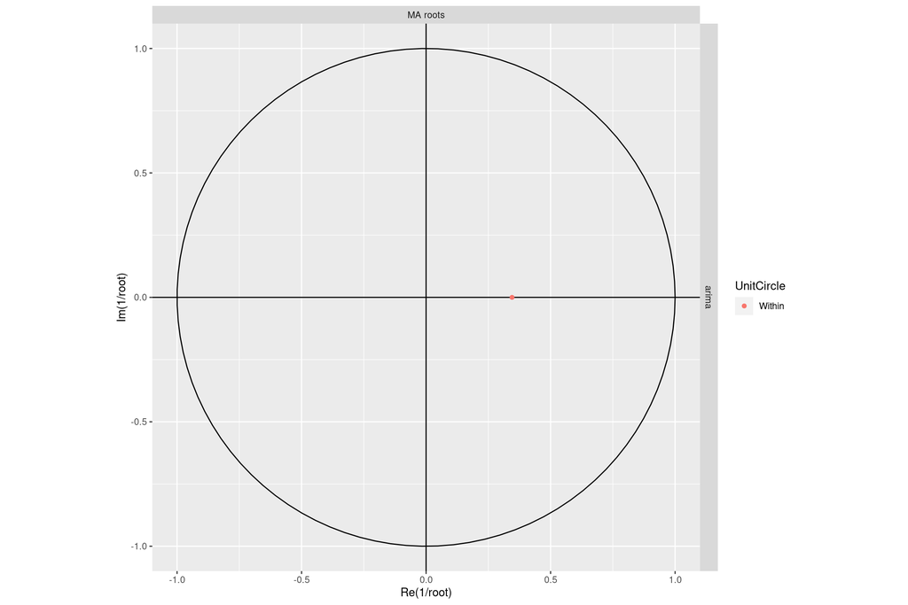

```r
gg_arma(fit2)
```

Hemos comprobado que los parámetros de este modelo son significativos y no existen problemas de invertivilidad. Dado que las gráficas de autocorrelaciones determinan que aún hay partes sin explicar, no evaluaremos los residuos.

Ajustamos ahora la parte estacional que nos falta, utilizando un SARIMA (0,1,1)x(0,1,1)$_{12}$

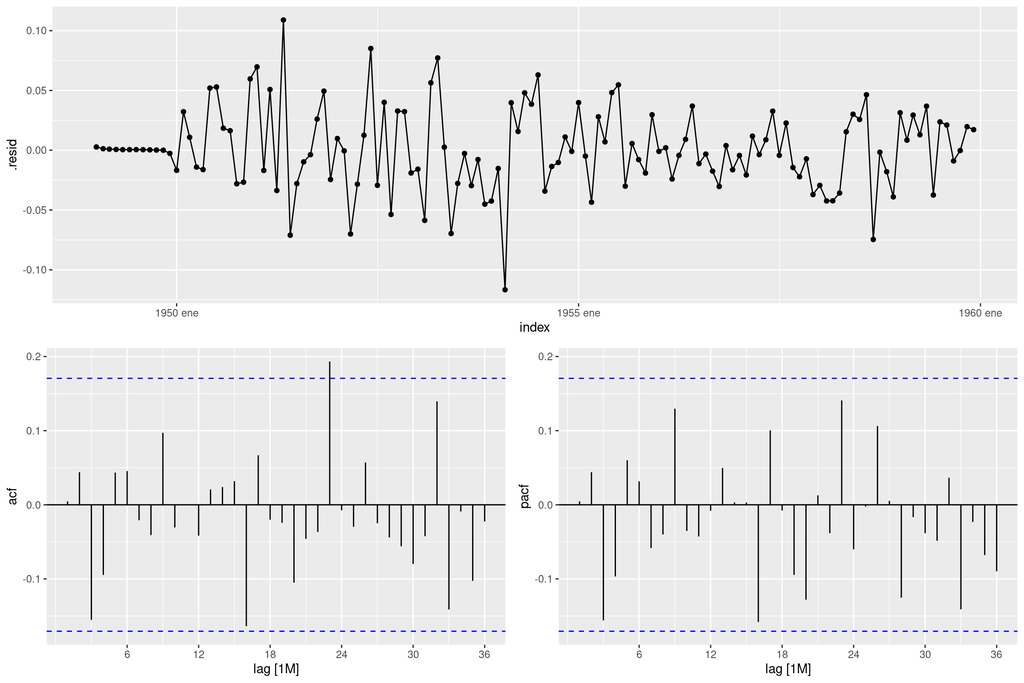

```r
fit3 <- air_train %>%
  model(arima = ARIMA(log(value) ~ pdq(0,1,1) + PDQ(0,1,1)))
fit3 %>% my_tsresiduals(lag_max =36)
```

La mayoría de los picos están dentro de las bandas, sólo uno se sale. Dado que estamos viendo 36 retardos, si se salieran hasta dos no sería significativo.

Comprobemos la calidad estadística de este nuevo modelo.

```r
report(fit3)
```

```
## Series: value
## Model: ARIMA(0,1,1)(0,1,1)[12]
## Transformation: log(value)
##
## Coefficients:
##           ma1     sma1
##       -0.3484  -0.5623
## s.e.   0.0943   0.0774
##
## sigma^2 estimated as 0.001338:  log likelihood=223.63
## AIC=-441.26   AICc=-441.05   BIC=-432.92
```

```r
my_t_test(fit3)
```

```
##
## t-test:
##              ma1     sma1
## t_stat   -3.6959  -7.2629
## p_value   0.0003   0.0000
```

Vemos que de nuevo todos los parámetros son significativos. Otra forma de evaluar si hay problemas con la invertibilidad es comprobar si el valor estimado del parámetro $\pm$ el error estándar, en valor absoluto, continene al 1. Por tanto, en este caso no hay problemas con la significatividad de los parámetros ni con la condición de invertibilidad.

## 5.1 Diagnosis de residuos

Para completar la fase de contraste evluamos los residuos. Veamos primero el histograma.

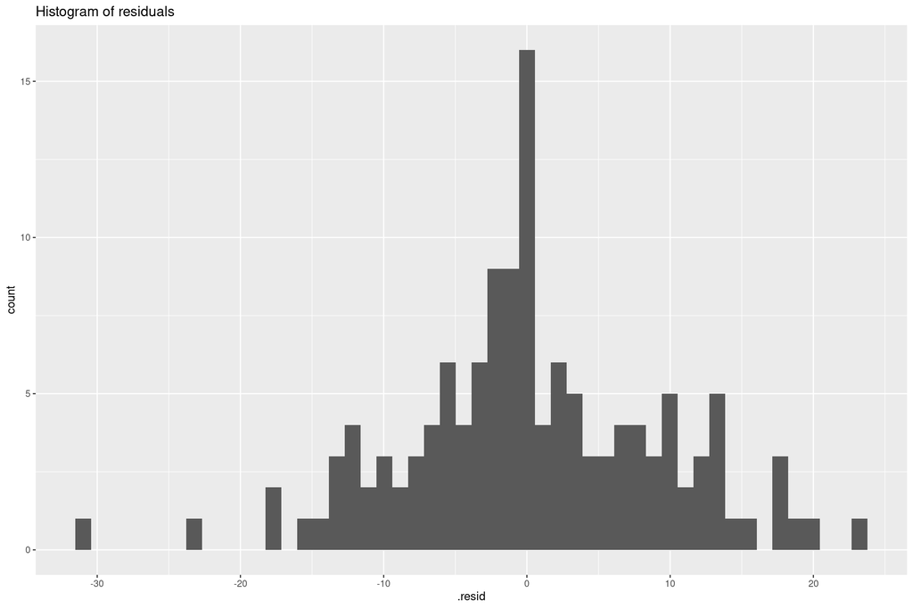

```r
aug <-fit3 %>% augment()

# Histogram
aug %>%
  ggplot(aes(x = .resid)) +
  geom_histogram(bins = 50) +
  ggtitle("Histogram of residuals")
```

### Test media = 0

Parece que la media es cero, pero distan bastante de la normalidad a priori. Procedemos a realizar un contraste t-student para contrastar si la media es 0.

```r
# Student's t-Test for mean=0
t.test(aug$.resid)
```

```
##
##  One Sample t-test
##
## data:  aug$.resid
## t = 0.32866, df = 131, p-value = 0.7429
## alternative hypothesis: true mean is not equal to 0
## 95 percent confidence interval:
##  -1.296702  1.813404
## sample estimates:
## mean of x
## 0.2583509
```

Como *p-value* > 0.05 no podemos rechazar la hipótesis de que la muestra tiene media 0.

### Test autocorrelaciones

A continuación comprobamos que los residuos están incorrelados.

```r
# Ljung-Box autocorrelation lag=2*m
aug %>% features(.resid, ljung_box, lag=24, dof=2)
```

| .model | lb_stat | lb_pvalue |
| --- | --- | --- |
| arima | 27.19641 | 0.2038614 |

```
## $values
## # A tibble: 24 x 3
##      lag  p_value incorelated
##    <int>    <dbl> <lgl>
##  1     1 NaN      NA
##  2     2   0      FALSE
##  3     3   0.156  TRUE
##  4     4   0.0389 FALSE
##  5     5   0.0879 TRUE
##  6     6   0.161  TRUE
##  7     7   0.254  TRUE
##  8     8   0.254  TRUE
##  9     9   0.178  TRUE
## 10    10   0.146  TRUE
## # … with 14 more rows
##
## $plot
```

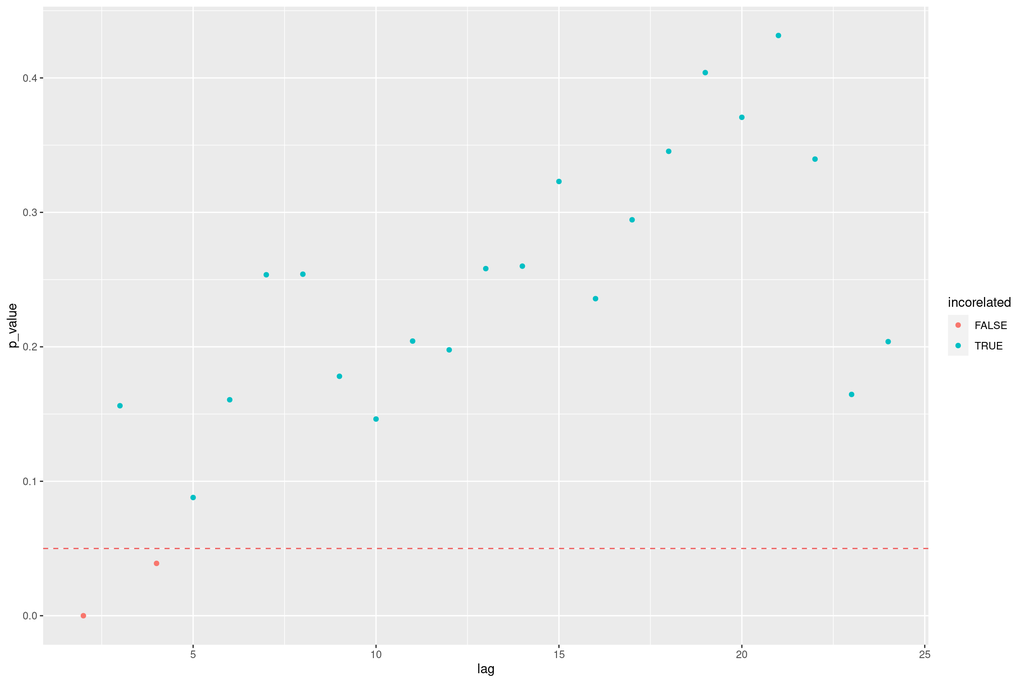

```r
pvals = autocorrelation_test_plot(aug, m = 12, dof = 2, h = 2, alpha = 0.05)
pvals
```

### Test homocedasticidad

Para contrastar la heterocedasticidad se puede utilizamos una regersión media-dispersión. Calculando los grupos de manera anual, dado que esa es la estacionalidad de la serie.

```r
log_log <- aug %>% as_tibble() %>%
  group_by(year(index)) %>%
  summarize(mean_resid = log(mean(.resid+1)), std_resid = log(sd(.resid+1)))
  summary(lm(std_resid~mean_resid, log_log))
```

```
##
## Call:
## lm(formula = std_resid ~ mean_resid, data = log_log)
##
## Residuals:
##     Min      1Q  Median      3Q     Max
## -3.3632  0.0412  0.4245  0.7675  1.0942
##
## Coefficients:
##             Estimate Std. Error t value Pr(>|t|)
## (Intercept)   1.3705     0.6584   2.081   0.0826 .
## mean_resid    0.3898     0.6373   0.612   0.5632
## ---
## Signif. codes:  0 '***' 0.001 '**' 0.01 '*' 0.05 '.' 0.1 ' ' 1
##
## Residual standard error: 1.537 on 6 degrees of freedom
##   (3 observations deleted due to missingness)
## Multiple R-squared:  0.05868,    Adjusted R-squared:  -0.0982
## F-statistic: 0.3741 on 1 and 6 DF,  p-value: 0.5632
```

Como el *p-valor* de *log(media)* es grande, entonces no se puede considerar distinto de 0 y, por tanto, los residuos son homocedásticos.

### Test de normalidad

Para contrastar la normalidad realizamos el test Jarque-Bera para evaluar la normalidad.

```r
# Jarque Bera test
jb.norm.test(na.omit(aug$.resid))
```

```
##
##  Jarque-Bera test for normality
##
## data:  na.omit(aug$.resid)
## JB = 2.5766, p-value = 0.215
```

Como el *p-valor* es mayor que el nivel de significancia 0.05, se acepta la hipótsis nula de normalidad de los resíduos.

# 6 Fase de predicción

Finalmente evaluamos la capacidad predictiva del modelo. Calculamos las predicciones en el conjunto de test, calculamos sus errores y los comparamos con los residuos.

```r
# Residual accuracy
resids <- fit3 %>%
  accuracy() %>%
  select(-c(.model, .type, ME, MPE, ACF1 )) %>%
  mutate(Evaluation='Training')

# Forecasting
fc <- fit3 %>%
  forecast(h=12)

test_err <- fc %>%
  accuracy(air) %>%
  select(-c(.model, .type, ME, MPE, ACF1 )) %>%
  mutate(Evaluation='Test')

# Show errors together
bind_rows(test_err, resids) %>% select(Evaluation, everything())
```

| Evaluation | RMSE | MAE | MAPE | MASE | RMSSE |
| --- | --- | --- | --- | --- | --- |
| Test | 19.385826 | 14.250116 | 3.10874 | 0.4679841 | 0.5611228 |
| Training | 9.000802 | 6.753838 | 2.58749 | 0.2218009 | 0.2605283 |

Además de evaluar los errores con estas medidas globales, podemos evaluar los errores cometidos año a año visualmente. Así, podemos detectar outliers o efectos de calendario no detectados. Pudiendo así corregirlos con modelos más complejos mediante variables exógenas.

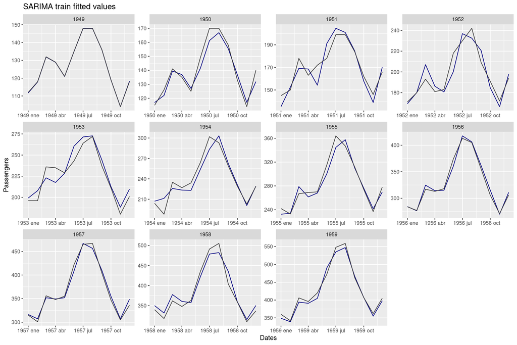

```r
aug %>%  ggplot() +
  geom_line(aes(x = index, y = .fitted), color="navy") +
  geom_line(aes(x = index, y = value), color="gray24") +
  # geom_line(data=air_forecast, aes(x = index, y = value), color="red4") +
  ggtitle("SARIMA train fitted values") +
  xlab('Dates') +
  ylab('Passengers') + facet_wrap(vars(year(index)), scales = 'free')
```

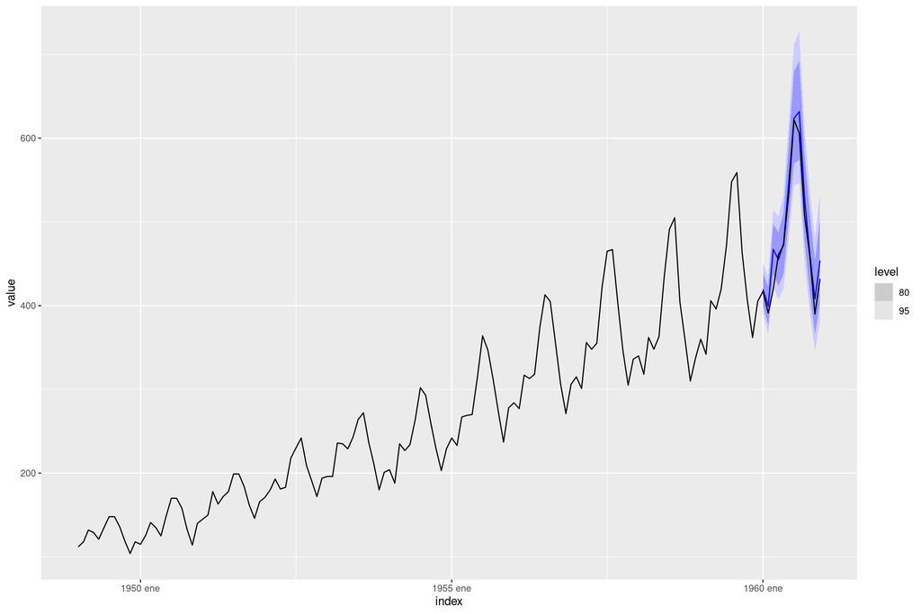

```r
fit3 %>%
  forecast(h=12) %>%
  autoplot(air)
```